# Topic 18

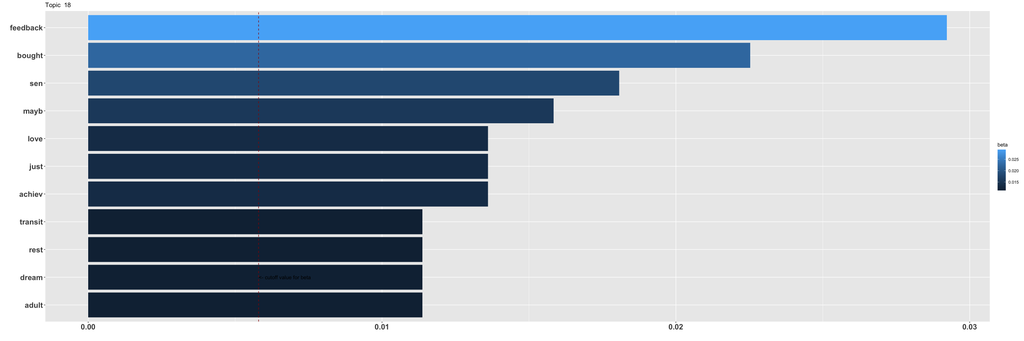

On interpreting beta: the term has a beta probability of being generated from the particular topic.

Values below are gamma : An estimated proportion of words from that document that are generated from that topic.

**Text Record Number: 75** gamma: 9 % likelihood of this document (based on its words) in this topic

**It does look good. The only thing I can think of is your weight distribution. Do you feel your weight go down through your sitting bones?

There is other things that you can’t gather from a picture. You need to be relaxed and feel free all the way through your arms and shoulders. Maybe a slight lean forward from where you are but not far.

I can’t see your feet either. Generally my right foot is at the pedal and my left foot is below my knee. Between the 2 feet and my bum I have 3 points of support when playing. The only time I lean back is if both hands are playing in the middle of the keyboard and I will sometimes lean forward if both hands are at the extreme right an left of the keys.

Your weight should distribute evenly between your bum bones unless you need to tilt left or right when both hands are playing high or low.

A couple of things you could check is the Taubman approach. See if they’ve got tips. That’s the method my teacher uses. Also Anderson technique.

There is a really sad book I read a while ago called ‘What Every Pianist Needs to Know About the Body’ by Thomas Mark. Might be worth a read. It talks about how your mind should map your body.

Good luck with it though. It’s a real shame when people can’t pursue their dreams or passions because of something like this. I have a friend who was an excellent golfer and had to give it up because of his back.

One more thing…. unless I’ve missed it, what part of your back hurts?**

**Text Record Number: 986** gamma: 9 % likelihood of this document (based on its words) in this topic

**I bought my piano from Bonners, but online! :)**

**Text Record Number: 1035** gamma: 9 % likelihood of this document (based on its words) in this topic

**The only time this is the case is with a tied note. If a note was sharped in the previous bar and tied to the next bar… it’s still sharp… but only so long as it’s still tied.

If you have to re-articulate that same note, it will need another sharp to keep it sharp.**

**Text Record Number: 1264** gamma: 9 % likelihood of this document (based on its words) in this topic

**Hello.We have a piano at home for years but I can’t really play it because I don’t know.But I really want to.But I don’t know where to start.I can only only sight read treble cleff and I can only comfortably sight read treble cleff between C4-B4 (I know bad…) I really can’t read bass cleff I count the notes with my fingers (embarassingly XD).I have no idea about music theory,I only know some minor and major scales but I have no idea why I learned them,if there is any point in learning them and what I am going to do with them after learning them???I have no idea what my level is and I don’t even know how a person can choose pieces that are appropriate for their level,I have no idea about that.I also don’t know any exercises(???) or something like that…And last but not least I cannot afford a teacher and I don’t want to sell the piano.And I don’t want to be professional or something like that but I would like to play the pieces I love and also if I advance a little bit play some pop songs by the ear?(I on’t know if thats a bad thing)Any help would be very much appreciated!(And sorry if I did mistakes writing the questions english is not my first language and I am in a hurry rn)**

**Text Record Number: 1371** gamma: 9 % likelihood of this document (based on its words) in this topic

**Looking for recommendations for piano/violin duets. Wife’s an intermediate violin player, I’m playing late beginner early intermediate piano pieces.

Any recommendations? So far we’re trying Goudon’s Ave Maria which for piano is basically Bach’s Prelude in C major**

**Text Record Number: 1418** gamma: 9 % likelihood of this document (based on its words) in this topic

**I’m 26 y/o wanting to learn how to play the piano. I am a beginner in every sense of the word and I am seeking a structural and foundational program to start out with. I’ve nailed it down to Alfred’d basic adult piano course and Pianote’s paid program. I’d love to get everyone’s feedback, opinions and experiences.

P.S. obviously I would love to hire a personal instructor but that is not an option for me at the moment so I am seeking virtual options only.

TIA!**

**Text Record Number: 581** gamma: 9 % likelihood of this document (based on its words) in this topic

**I’ve been learning for 2-3 months now. I bought a few books but the one that helped me at first was kids book, playing nursery rhymes! One of the books I bought I have found pretty useless because it was theory and practise drills and zero fun!

The next book I have is Easy Piano songs for beginners which I am working my way through

I’ve been learning for 2-3 months now. I bought a few books but the one that helped me at first was a kids book, playing nursery rhymes! One of the books I bought I have found pretty useless because it was theory and practise drills and zero fun!

I can play Amazing Grace, Let it Be, Silent Night, All Things Bright and Beautiful and some others so far

I get a sense of achievement and satisfaction once I can play a song without errors

Maybe not the most advanced method of learning but this is the way that has worked for me (so far). I don’t like being on a course I like t do my own thing so I buy a few books and find some songs that are not too difficult but not too easy and then try to advance like that**